# Home assignment 02: Data analysis Task 6

This is the second Almaz Murzabekov’s home assignment of Data analysis Task 6

### 6 Assignment on Clustering

Get the built-in data with at least 4 quantitative (continuous) variables.

```r
library(FactoMineR)
data(USArrests)
```

The USArrests data set contains statistics, in arrests per 100,000 residents for assault, murder, and rape in each of the 50 US states in 1973. Also given is the percent of the population living in urban areas. The dataset contains 4 variables: - Murder numeric Murder arrests (per 100,000) - Assault numeric Assault arrests (per 100,000) - UrbanPop numeric Percent urban population - Rape numeric Rape arrests (per 100,000)

```r
USArrests
```

|  | Murder | Assault | UrbanPop | Rape |
| --- | --- | --- | --- | --- |
| Alabama | 13.2 | 236 | 58 | 21.2 |
| Alaska | 10.0 | 263 | 48 | 44.5 |
| Arizona | 8.1 | 294 | 80 | 31.0 |
| Arkansas | 8.8 | 190 | 50 | 19.5 |
| California | 9.0 | 276 | 91 | 40.6 |
| Colorado | 7.9 | 204 | 78 | 38.7 |
| Connecticut | 3.3 | 110 | 77 | 11.1 |
| Delaware | 5.9 | 238 | 72 | 15.8 |
| Florida | 15.4 | 335 | 80 | 31.9 |
| Georgia | 17.4 | 211 | 60 | 25.8 |

[output cut: 40 more lines]

1. Do the hierarchical clustering (preceded by the PCA) using command HCPC from FactoMineR package:
   1. Clearly name the recommended (by HCPC) clusters.

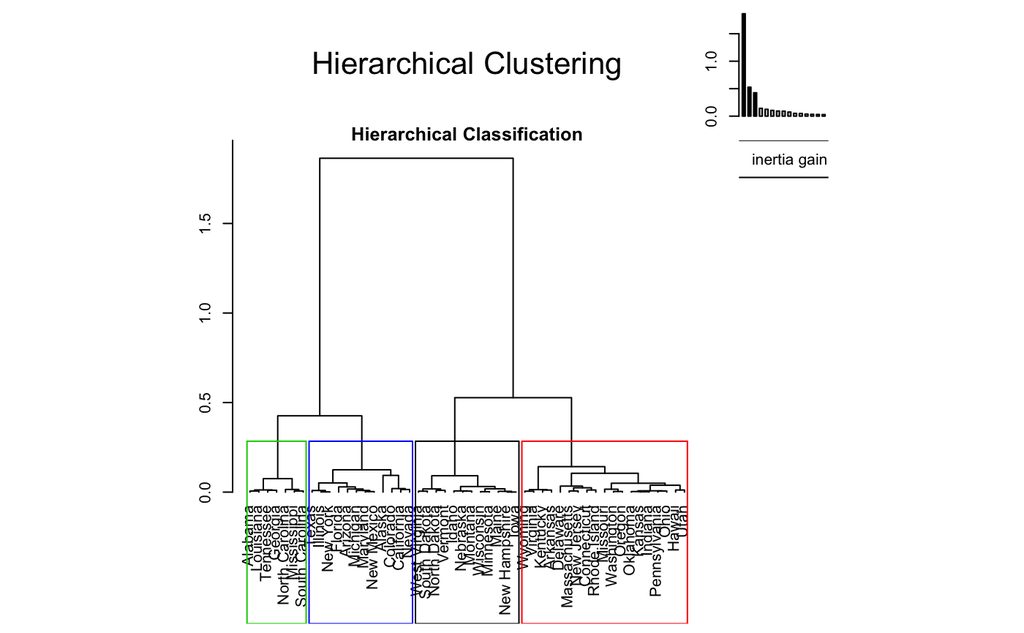

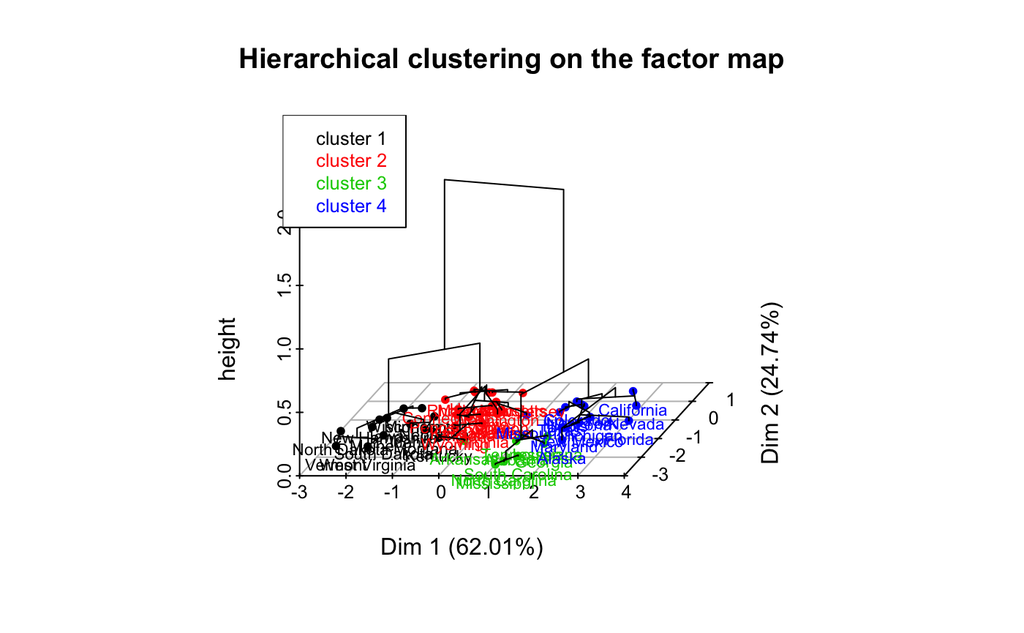

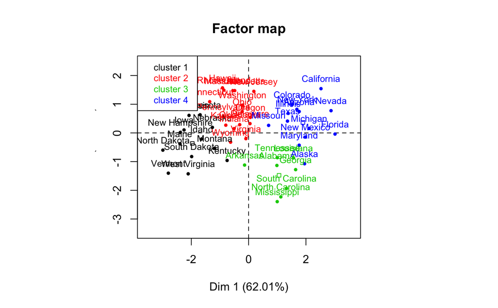

```r
    library(FactoMineR)
    library(factoextra)

    res_pca = PCA(USArrests, graph = FALSE)
    res.hcpc = HCPC(res_pca, nb.clust = 4)
```

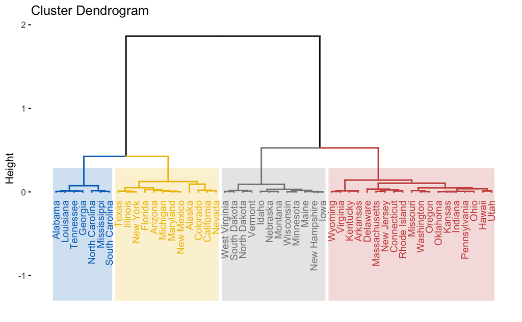

```r
library(factoextra)

fviz_dend(res.hcpc,
          cex = 0.7,                     # Label size
          palette = "jco",               # Color palette see ?ggpubr::ggpar
          rect = TRUE,
          rect_fill = TRUE, # Add rectangle around groups
          rect_border = "jco",           # Rectangle color
          labels_track_height = 0.8      # Augment the room for labels
          )
```

```
(b) Explain the meaning of the barplot in the upper-right corner of the output.
```

2. Perform the K-means clustering, choosing K according to the results of hierarchical clustering.

```r
library(factoextra)

set.seed(99)

input <- na.omit(USArrests)

km_res = kmeans(input, centers = 4, nstart = 20)
km_res
```

```
K-means clustering with 4 clusters of sizes 14, 16, 10, 10

Cluster means:
     Murder  Assault UrbanPop     Rape
1  8.214286 173.2857 70.64286 22.84286
2 11.812500 272.5625 68.31250 28.37500
3  2.950000  62.7000 53.90000 11.51000
4  5.590000 112.4000 65.60000 17.27000

Clustering vector:
       Alabama         Alaska        Arizona       Arkansas     California       Colorado    Connecticut       Delaware        Florida        Georgia         Hawaii          Idaho       Illinois        Indiana
             2              2              2              1              2              1              4              2              2              1              3              4              2              4
          Iowa         Kansas       Kentucky      Louisiana          Maine       Maryland  Massachusetts       Michigan      Minnesota    Mississippi       Missouri        Montana       Nebraska         Nevada
             3              4              4              2              3              2              1              2              3              2              1              4              4              2
 New Hampshire     New Jersey     New Mexico       New York North Carolina   North Dakota           Ohio       Oklahoma         Oregon   Pennsylvania   Rhode Island South Carolina   South Dakota      Tennessee
             3              1              2              2              2              3              4              1              1              4              1              2              3              1
         Texas           Utah        Vermont       Virginia     Washington  West Virginia      Wisconsin        Wyoming
             1              4              3              1              1              3              3              1

Within cluster sum of squares by cluster:
[1]  9136.643 19563.863  4547.914  1480.210
 (between_SS / total_SS =  90.2 %)

Available components:

[1] "cluster"      "centers"      "totss"        "withinss"     "tot.withinss" "betweenss"    "size"         "iter"         "ifault"
```

```
(a) Plot the results
```

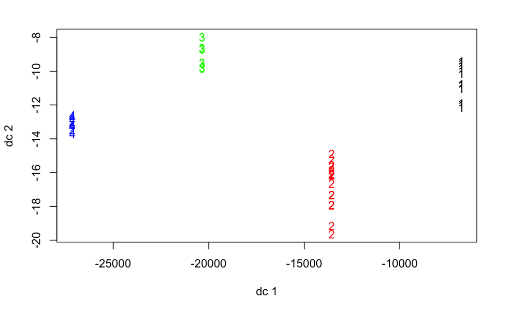

```r
library(cluster)
library(fpc)

plot_data = cbind(input, cluster = km_res$cluster)

plotcluster(plot_data, km_res$cluster)
```

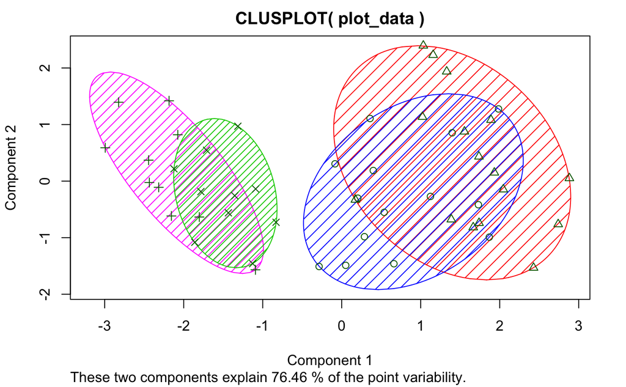

```r
clusplot(plot_data, km_res$cluster, color = TRUE, shade = TRUE, lines = 100)
```

[output not shown]

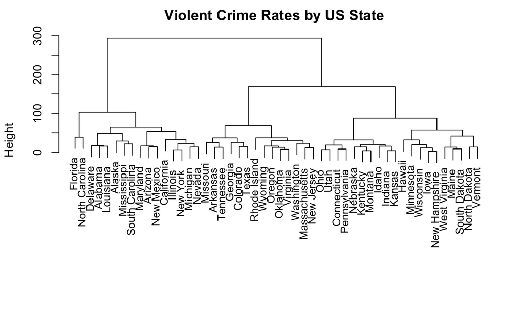

```r
hc_complete = hclust(dist(input), method="complete")

plot(hc_complete ,main="Violent Crime Rates by US State ", xlab="", sub="", cex=.9)
```